# Decision Prediction and Cost Benefit Analysis

Zhijie Zhou (Partner: Chi Zhang)

10/30/2020

## Motivation

The woefully inadequate uptake of the house-repairing tax credit program in Emil City has driven the city's Department of Housing and Community Development (HCD) to strive for a better understanding of the willingness of eligible homeowners and more effectively targeting resource allocation. Based on client-level data collected from previous campaigns, we developed a decision-making analytic.

Our analytics rely on the following criteria/assumptions: 1. For the household predicted to take the tax credit, HCD is willing to allocate **$2,850** per homeowner which includes staff and resources to facilitate mailers, phone calls, and information/counseling sessions at the HCD offices. 2. We assume **25%** of contacted eligible homeowners, i.e., who received the marketing allocation, would take the tax credit, while the remaining 75% would not take the credit. 3. The credit costs **$5,000** per homeowner which can be used toward home improvement. Academic researchers in Philadelphia evaluated the program finding that houses that transacted after taking the credit, sold with a **$10,000** premium, on average.

## Setup

Libraries used in this project: `tidyverse`, `kableExtra`, `caret`, `knitr`, `pscl`, `plotROC`, `pROC`, `lubridate`. Please see the hiden code chunk for more info.

Functions/Data Source: *Public Policy Analytics* by Ken Steif

```r
options(scipen=9999)

library(tidyverse)
library(kableExtra)
library(caret)
library(knitr)
library(pscl)
library(plotROC)
library(pROC)
library(lubridate)
library(gridExtra)

palette5 <- c("#981FAC","#CB0F8B","#FF006A","#FE4C35","#FE9900")
palette4 <- c("#981FAC","#FF006A","#FE4C35","#FE9900")
palette2 <- c("#981FAC","#FF006A")

root.dir = "https://raw.githubusercontent.com/urbanSpatial/Public-Policy-Analytics-Landing/master/DATA/"

source("https://raw.githubusercontent.com/urbanSpatial/Public-Policy-Analytics-Landing/master/functions.r")

housingSubsidy <- read.csv(file.path(root.dir,"/Chapter6/housingSubsidy.csv"))
```

## Exploratory Analysis

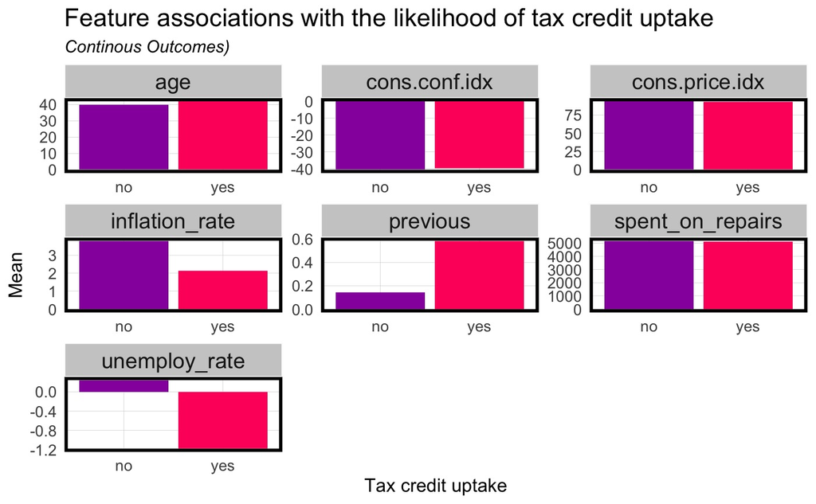

Figure 1.1(A)

```r
housingSubsidy %>%
  dplyr::select(y, age, previous, unemploy_rate, cons.price.idx,
                cons.conf.idx, inflation_rate, spent_on_repairs) %>%
  gather(Variable, value, -y) %>%
  ggplot(aes(y, value, fill=y)) +
    geom_bar(position = "dodge", stat = "summary", fun = "mean") +
    facet_wrap(~Variable, scales = "free") +
    scale_fill_manual(values = palette2) +
    labs(x="Tax credit uptake", y="Mean",
         title = "Feature associations with the likelihood of tax credit uptake",
         subtitle = "Continous Outcomes)") +
    plotTheme() + theme(legend.position = "none")
```

From Figure 1.1(A) above, we can identify that the changes in `inflation_rate` (daily indicator of inflation - on the day of contacting), `previous` (times that the household has been contacted previously), and `unemploy_rate` (unemployment indicator on the day of contacting) are more likely to correlate with a houseowner's decision on taking up the housing repair tax credit, as the mean values of those variables corresponding to "yes" and "no" of tax credit uptake differ a lot. The other variables have similar mean values across "yes" and "no".

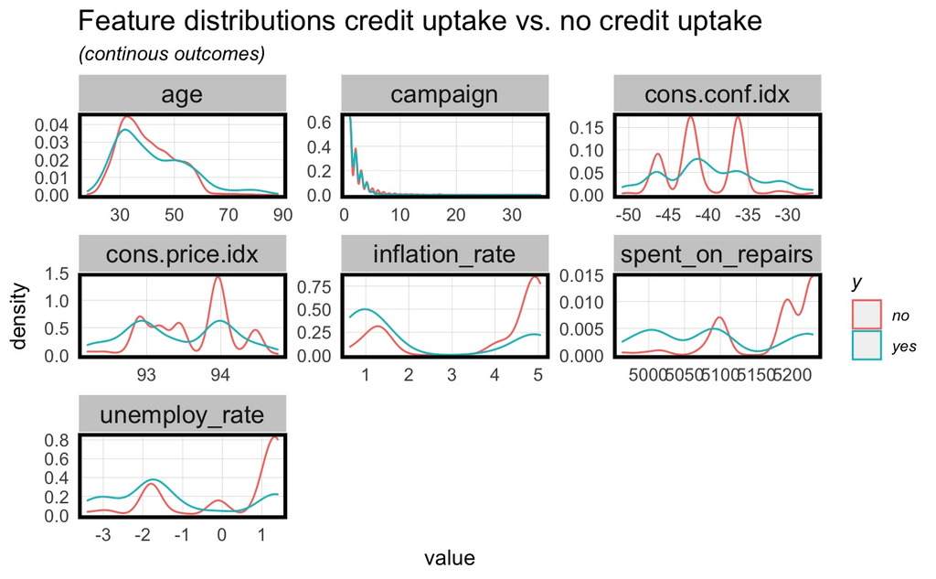

```r
housingSubsidy %>%
  dplyr::select(y,cons.conf.idx, inflation_rate, spent_on_repairs, cons.price.idx, age, campaign, unemploy_rate) %>%
  gather(Variable, value, -y) %>%
  ggplot() +
  geom_density(aes(value, color=y), fill = "transparent") +
  facet_wrap(~Variable, scales = "free") +
  scale_fill_manual(values = palette2) +
  labs(title = "Feature distributions credit uptake vs. no credit uptake",
       subtitle = "(continous outcomes)") + plotTheme()
```

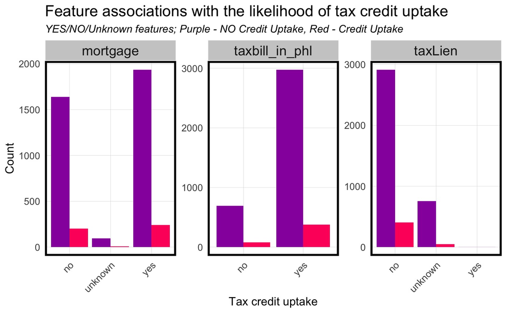

```r
housingSubsidy %>%
  dplyr::select(y, taxbill_in_phl, mortgage, taxLien) %>%
  gather(Variable, value, -y) %>%
  count(Variable, value, y) %>%
  ggplot(aes(value, n, fill = y)) +
    geom_bar(position = "dodge", stat="identity") +
    facet_wrap(~Variable, scales="free") +
    scale_fill_manual(values = palette2) +
    labs(x="Tax credit uptake", y="Count",
         title = "Feature associations with the likelihood of tax credit uptake",
         subtitle = "YES/NO/Unknown features; Purple - NO Credit Uptake, Red - Credit Uptake") +
    plotTheme() + theme(legend.position = 'none', axis.text.x = element_text(angle = 45, hjust = 1))
```

The three features, `mortgage`, `taxbill_in_phl`, and `taxLien` shown in Figure 2 stand for binary features (with a few exceptions of "unknown" answers). Most households in the housingSubsidy dataset did not take up the tax credit, and in each feature here there are more households not taking up the tax than those taking up. And note there are no "yes" answers of whether the household has a lien against its property. So that feature might not influence the selling prices (or whether to take up the tax credit).

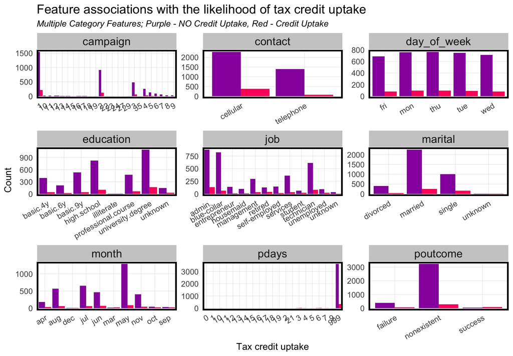

```r
housingSubsidy %>%
  dplyr::select(y, job, marital,
                education, contact, month, day_of_week, campaign,
                pdays, poutcome) %>%
  gather(Variable, value, -y) %>%
  count(Variable, value, y) %>%
    ggplot(aes(value, n, fill = y)) +
      geom_bar(position = "dodge", stat="identity") +
      facet_wrap(~Variable, scales = "free", ncol=3) +
      scale_fill_manual(values = palette2) +
      labs(x="Tax credit uptake", y="Count",
           title = "Feature associations with the likelihood of tax credit uptake",
           subtitle = "Multiple Category Features; Purple - NO Credit Uptake, Red - Credit Uptake") +
      plotTheme() + theme(legend.position = "none", axis.text.x = element_text(angle = 30, hjust = 1))
```

Multiple category features generate a bit messy patterns. "Yes" or "No" on tax credit uptake evenly distribute accross `day_of_week`, which is not surprising, since there might not exist a "magic day" of marketing.`poutcome` is linked with `pdays` since most houseowners are in "999" for pdays and "nonexistent" for poutcome - both indicate that the client has not been contacted previously. We probably need to rely on the logistic regression model to understand the other variables' correlation with tax credit uptake.

## Logistic Regression Model

A logistic regression model predicts a binary outcome - a `1` or a `0` - a `Take Credit` or a `Not Take Credit` and associates a coefficient that describes the change in the probability of the outcome given some change in the independent variable.

We first partition our data into a 65/35 training and test set (`p = .65`). We call these sets `creditTrain` and `creditTest`.

```r
set.seed(34567)
trainIndex1 <- createDataPartition(housingSubsidy$y, p = .65,
                                  y = paste(housingSubsidy$taxLien, housingSubsidy$education),
                                  list = FALSE,
                                  times = 1)
creditTrain1 <- housingSubsidy[ trainIndex1,]
creditTest1  <- housingSubsidy[-trainIndex1,]
```

### Baseline Model ("Kitchen Sink"?)

We run our model with the dependent variable `y_numeric` and we use most of our variables in the regression as our baseline model (See `dplyr::select`).

```r
creditModel1 <- glm(y_numeric ~ .,
                  data=creditTrain1 %>%
                    dplyr::select(-X, -y),
                  family="binomial" (link="logit"))
```

### Feature-Engineered Model

We modified `age` and `education` into more general categories in order to increase the model's performance. Instead of listing ages of the homeowners in a continuous way, we categorize them into four main categories: "YOUNG" represents homeowner younger than 30 years old; "MIDDLE_YOUNG" stands for those between 30 and 45 years old; "MIDDLE" for those between 45 and 65 years old; and finally, "SENIOR" for those above 65. Similarly, the education attributes are classified into "BASIC" (basic.4y, basic.6y, basic.9y), "HIGHSCHOOL" (high.school), "HIGHER" (professional.course and university.degree), and "OTHER". With grouped attributes we may better catch the patterns of those homeowners on whether they would like to takeup the credit tax.

```r
features_en <- housingSubsidy %>%
  mutate(ageGroup = case_when(age < 30 ~ "YOUNG",
                              age >= 30 & age < 45 ~ "MIDDLE_YOUNG",
                              age >= 45 & age < 65 ~ "MIDDLE",
                              age >= 65 ~ "SENIOR"),
         eduGroup = case_when(education == 'basic.4y' | education == 'basic.6y' | education == 'basic.9y' ~ "BASIC",
                              education == 'high.school' ~ "HIGHSCHOOL",
                              education == 'professional.course' | education == 'university.degree' ~ "HIGHER",
                              TRUE ~ 'OTHER')
         # unemploy_rate.cat = case_when(unemploy_rate >= 0 ~ 'UP', TRUE ~ "DOWN")
         # inflationGroup = case_when(inflation_rate >= 3 ~ 'HIGH_INF',
         #                            TRUE ~ "LOW_INF")
         # pdays.cat = case_when(pdays < 999 ~ "CONTACTED",
         #                       pdays == 999 ~ "NEVER")
         )
```

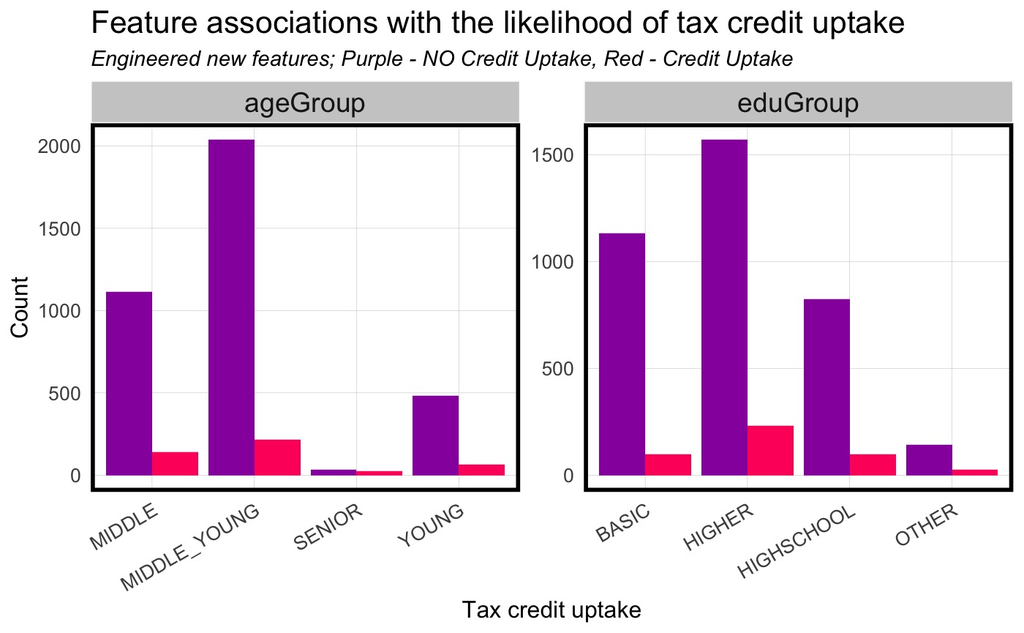

Figure 2.1

```r
features_en %>%
  dplyr::select(y, ageGroup, eduGroup) %>%
  gather(Variable, value, -y) %>%
  count(Variable, value, y) %>%
    ggplot(aes(value, n, fill = y)) +
      geom_bar(position = "dodge", stat="identity") +
      facet_wrap(~Variable, scales = "free", ncol=3) +
      scale_fill_manual(values = palette2) +
      labs(x="Tax credit uptake", y="Count",
           title = "Feature associations with the likelihood of tax credit uptake",
           subtitle = "Engineered new features; Purple - NO Credit Uptake, Red - Credit Uptake") +
      plotTheme() + theme(legend.position = "None", axis.text.x = element_text(angle = 30, hjust = 1))
```

```r
set.seed(345678)
trainIndex2 <- createDataPartition(features_en$y, p = .65,
                                   y = paste(features_en$eduGroup,
                                             features_en$ageGroup),
                                  list = FALSE,
                                  times = 1)

creditTrain2 <- features_en[ trainIndex2,]
creditTest2  <- features_en[-trainIndex2,]

creditModel2 <- glm(y_numeric ~ .,
                  data=creditTrain2 %>%
                    dplyr::select(-X, -y, -poutcome, -age, -education, -taxLien,
                                  -previous, -mortgage, -unemploy_rate),
                  family="binomial" (link="logit"))
```

These predictions are the estimated probabilities of tax credit uptake for these out-of-sample subjects.

```r
testProbs1 <- data.frame(Outcome = as.factor(creditTest1$y_numeric),
                        Probs = predict(creditModel1, creditTest1, type= "response"))
testProbs2 <- data.frame(Outcome = as.factor(creditTest2$y_numeric),
                        Probs = predict(creditModel2, creditTest2, type= "response"))
testProbs1 <-
  testProbs1 %>%
  mutate(predOutcome  = as.factor(ifelse(testProbs1$Probs > 0.5 , 1, 0)))
testProbs2 <-
  testProbs2 %>%
  mutate(predOutcome  = as.factor(ifelse(testProbs2$Probs > 0.5 , 1, 0)))
```

For the "kitchen sink" model:

```r
caret::confusionMatrix(testProbs1$predOutcome, testProbs1$Outcome,
                       positive = "1")
```

```
## Confusion Matrix and Statistics
##
##           Reference
## Prediction    0    1
##          0 1242  133
##          1   24   33
##
##                Accuracy : 0.8904
##                  95% CI : (0.873, 0.9061)
##     No Information Rate : 0.8841
##     P-Value [Acc > NIR] : 0.2431
##
##                   Kappa : 0.2516
##
##  Mcnemar's Test P-Value : <0.0000000000000002
##
##             Sensitivity : 0.19880
##             Specificity : 0.98104
##          Pos Pred Value : 0.57895
##          Neg Pred Value : 0.90327
##              Prevalence : 0.11592
##          Detection Rate : 0.02304
##    Detection Prevalence : 0.03980
##       Balanced Accuracy : 0.58992
##
##        'Positive' Class : 1
##
```

For the feature-engineered model:

```r
caret::confusionMatrix(testProbs2$predOutcome, testProbs2$Outcome,
                       positive = "1")
```

```
## Confusion Matrix and Statistics
##
##           Reference
## Prediction    0    1
##          0 1252  118
##          1   17   48
##
##                Accuracy : 0.9059
##                  95% CI : (0.8896, 0.9205)
##     No Information Rate : 0.8843
##     P-Value [Acc > NIR] : 0.00495
##
##                   Kappa : 0.3749
##
##  Mcnemar's Test P-Value : < 0.0000000000000002
##
##             Sensitivity : 0.28916
##             Specificity : 0.98660
##          Pos Pred Value : 0.73846
##          Neg Pred Value : 0.91387
##              Prevalence : 0.11568
##          Detection Rate : 0.03345
##    Detection Prevalence : 0.04530
##       Balanced Accuracy : 0.63788
##
##        'Positive' Class : 1
##
```

```r
# Regression results output
library(sjPlot)
library(sjmisc)
library(sjlabelled)

tab_model(creditModel1, creditModel2, auto.label = TRUE, show.ci = FALSE, show.intercept = FALSE,
          title = 'Summary of Logistic Regression Results',
          dv.labels = c("Kitchen Sink", "Feature Engineering"),
          string.pred = "Coefficient")
```

[output not shown]

We exponentiate a coefficeint and produce an 'odds ratio', which can be explained as: "All else equal, a person having {the coefficient} reduces the likelihood of taking up the tax credit by {odds ratio} .For continuous variables, a unit increase in the independent variable increase the likelihood of tax credit uptake by a certain percentage.

### Cross Validation

```r
ctrl <- trainControl(method = "cv", number = 100,
                     classProbs=TRUE, summaryFunction=twoClassSummary)

cvFit1 <- train(y~., data = housingSubsidy %>%
                                   dplyr::select(-X, -y_numeric),
                method="glm", family="binomial",
                metric="ROC", trControl = ctrl)
```

For the "kitchen sink" all-in model:

```
## Generalized Linear Model
##
## 4119 samples
##   19 predictor
##    2 classes: 'no', 'yes'
##
## No pre-processing
## Resampling: Cross-Validated (100 fold)
## Summary of sample sizes: 4078, 4077, 4079, 4079, 4077, 4077, ...
## Resampling results:
##
##   ROC        Sens       Spec
##   0.7674159  0.9806006  0.221
```

```r
cvFit2 <- train(y~., data = features_en %>%
                                   dplyr::select(-X, -y_numeric, -poutcome, -age, -education, -taxLien,
                                  -previous, -mortgage, -unemploy_rate),
                method="glm", family="binomial",
                metric="ROC", trControl = ctrl)
```

For the feature engineering model:

```
## Generalized Linear Model
##
## 4119 samples
##   14 predictor
##    2 classes: 'no', 'yes'
##
## No pre-processing
## Resampling: Cross-Validated (100 fold)
## Summary of sample sizes: 4078, 4079, 4079, 4079, 4079, 4078, ...
## Resampling results:
##
##   ROC        Sens       Spec
##   0.7651269  0.9828529  0.2285
```

The facetted plots of ROC, Sensitivity and Specificity of both models are shown below.

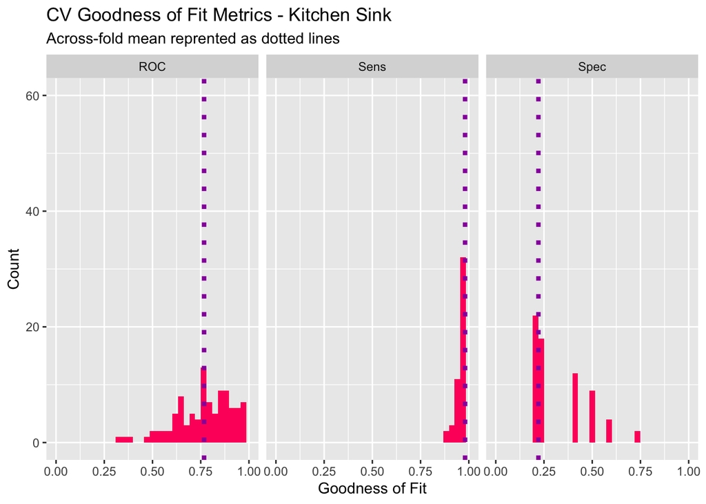

```r
dplyr::select(cvFit1$resample, -Resample) %>%
  gather(metric, value) %>%
  left_join(gather(cvFit1$results[2:4], metric, mean)) %>%
  ggplot(aes(value)) +
    geom_histogram(bins=35, fill = "#FF006A") +
    facet_wrap(~metric) +
    geom_vline(aes(xintercept = mean), colour = "#981FAC", linetype = 3, size = 1.5) +
    scale_x_continuous(limits = c(0, 1)) +
    ylim(low = 0, high = 60) +
    labs(x="Goodness of Fit", y="Count", title="CV Goodness of Fit Metrics - Kitchen Sink",
         subtitle = "Across-fold mean reprented as dotted lines")
```

Figure 2.2(A)

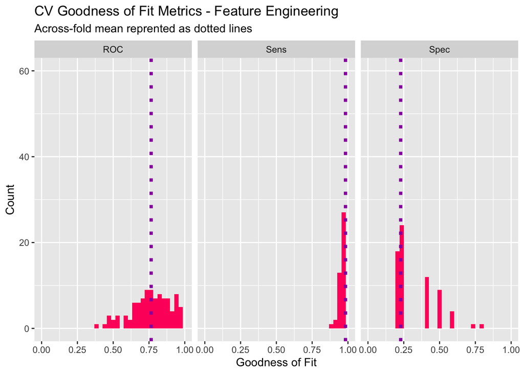

```r
dplyr::select(cvFit2$resample, -Resample) %>%
  gather(metric, value) %>%
  left_join(gather(cvFit2$results[2:4], metric, mean)) %>%
  ggplot(aes(value)) +
    geom_histogram(bins=35, fill = "#FF006A") +
    facet_wrap(~metric) +
    geom_vline(aes(xintercept = mean), colour = "#981FAC", linetype = 3, size = 1.5) +
    scale_x_continuous(limits = c(0, 1)) +
    ylim(low = 0, high = 60) +
    labs(x="Goodness of Fit", y="Count", title="CV Goodness of Fit Metrics - Feature Engineering",
         subtitle = "Across-fold mean reprented as dotted lines")
```

Figure 2.2(B)

### Receiver Operating Characteristic (ROC) Curve

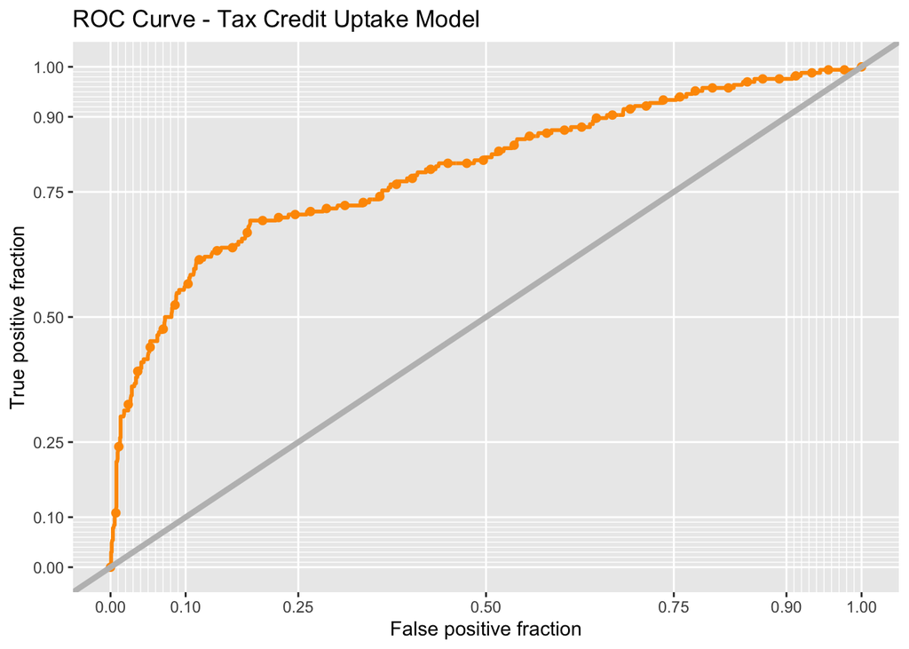

```r
ggplot(testProbs2, aes(d = as.numeric(testProbs2$Outcome), m = Probs)) +
  geom_roc(n.cuts = 50, labels = FALSE, colour = "#FE9900") +
  style_roc(theme = theme_grey) +
  geom_abline(slope = 1, intercept = 0, size = 1.5, color = 'grey') +
  labs(title = "ROC Curve - Tax Credit Uptake Model")
```

```r
auc(testProbs2$Outcome, testProbs2$Probs)
```

```
## Area under the curve: 0.7926
```

Figure 2.3

The Receiver Operating Characteristic (ROC) curve illustrates trade-offs between True Positive and False Positive - two vital confusion metrics and offers a measurement of goodness of fit indicator. The curve is above the diagonal line (also known as the 'Coin Flip line' with an equal, corresponding false positive rate for each true positive rate on the line). The model would get it right about 70% of time and 25% of time false.

The 'Area Under the Curve' metric or AUC for the feature-engineered model is 0.7926, which is reasonable since the range of AUC should be [0.5, 1].

## Cost-Benefit Analysis

Here we define the cost/benefit equations of the four kinds of outcome (confusion metric) as follows:

`True_Negative`: Count * 0 (no campaign cost and no benefit).

`True_Positive`: Count * 0.25 *(10000 (premium when sold) + 56000 (surrounding aggregate premium) - 2850 (campaign cost) - 5000 (credit))

`False_Negative`: Count * 0 (zero out mannualy, not related to the campaign).

`False_Positive`: Count * (-2850) (campaign cost).

```r
cost_benefit_table <-
   testProbs2 %>%
      count(predOutcome, Outcome) %>%
      summarize(True_Negative = sum(n[predOutcome==0 & Outcome==0]),
                True_Positive = sum(n[predOutcome==1 & Outcome==1]),
                False_Negative = sum(n[predOutcome==0 & Outcome==1]),
                False_Positive = sum(n[predOutcome==1 & Outcome==0])) %>%
       gather(Variable, Count) %>%
       mutate(Revenue =
               ifelse(Variable == "True_Negative", Count * 0,
               ifelse(Variable == "True_Positive", (10000+56000-5000-2850) * Count * 0.25,
               ifelse(Variable == "False_Negative", Count * 0,
               ifelse(Variable == "False_Positive", (-2850) * Count, 0))))) %>%
    bind_cols(data.frame(Description = c(
              "Predicted correctly homeowner would not take the credit, no marketing resources were allocated, and no credit was allocated",
              "Predicted correctly homeowner would take the credit; allocated the marketing resources, and 25% took the credit",
              "We predicted that a homeowner would not take the credit but they did - probably unrelated to the marketing campaign",
              "Predicted incorrectly homeowner would take the credit; allocated marketing resources; no credit allocated")))
```

```r
kable(cost_benefit_table,
       caption = "Cost/Benefit Table") %>%   kable_styling(font_size = 12, full_width = F,
                bootstrap_options = c("striped", "hover", "condensed"))
```

Cost/Benefit Table

| Variable | Count | Revenue | Description |
| --- | --- | --- | --- |
| True_Negative | 1252 | 0 | Predicted correctly homeowner would not take the credit, no marketing resources were allocated, and no credit was allocated |
| True_Positive | 48 | 697800 | Predicted correctly homeowner would take the credit; allocated the marketing resources, and 25% took the credit |
| False_Negative | 118 | 0 | We predicted that a homeowner would not take the credit but they did - probably unrelated to the marketing campaign |
| False_Positive | 17 | -48450 | Predicted incorrectly homeowner would take the credit; allocated marketing resources; no credit allocated |

Here is a function to iterate through the thresholds.

```r
iterateThresholds <- function(data) {
  x = .01
  all_prediction <- data.frame()
  while (x <= 1) {
    this_prediction <-
        testProbs2 %>%
        mutate(predOutcome = ifelse(Probs > x, 1, 0)) %>%
        count(predOutcome, Outcome) %>%
        summarize(True_Negative = sum(n[predOutcome==0 & Outcome==0]),
                  True_Positive = sum(n[predOutcome==1 & Outcome==1]),
                  False_Negative = sum(n[predOutcome==0 & Outcome==1]),
                  False_Positive = sum(n[predOutcome==1 & Outcome==0])) %>%
       gather(Variable, Count) %>%
       mutate(Revenue =
               ifelse(Variable == "True_Negative", Count * 0,
               ifelse(Variable == "True_Positive", (10000+56000-5000-2850) * Count * 0.25,
               ifelse(Variable == "False_Negative", Count * 0,
               ifelse(Variable == "False_Positive", (-2850) * Count, 0)))),
              Threshold = x)

    all_prediction <- rbind(all_prediction, this_prediction)
    x <- x + .01
  }
return(all_prediction)
}
```

```r
whichThreshold <- iterateThresholds(testProbs2)
```

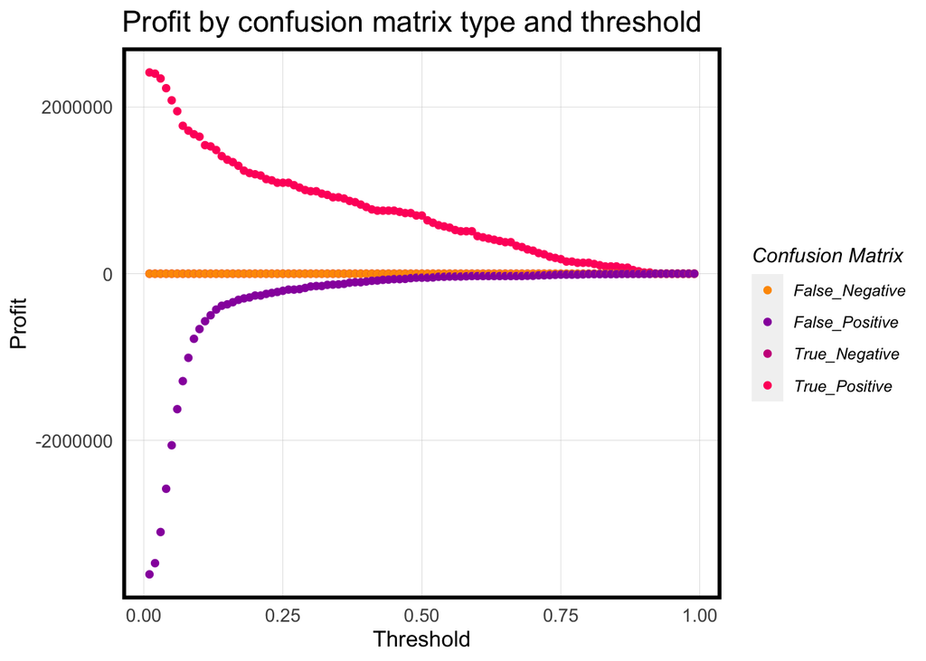

```r
whichThreshold %>%
  ggplot(.,aes(Threshold, Revenue, colour = Variable)) +
  geom_point() +
  scale_colour_manual(values = palette5[c(5, 1:3)]) +
  labs(title = "Profit by confusion matrix type and threshold",
       y = "Profit") +
  plotTheme() +
  guides(colour=guide_legend(title = "Confusion Matrix"))
```

Figure 3.1

We would like to create plots showing `Threshold` as a function of `Total_Revenue` and `Total_Count_of_Credits` respectively.

```r
whichThreshold_sum <-
  whichThreshold %>%
    mutate(actualCredit = ifelse(Variable == "True_Positive", (Count * .25),
                          ifelse(Variable == "False_Negative", Count, 0) )) %>%
   group_by(Threshold) %>%
    summarize(Total_Revenue = sum(Revenue),
              Total_Count_of_Credits = sum(actualCredit))

optimalThreshold <- pull(arrange(whichThreshold_sum, -Total_Revenue)[1,1])
fiftyPercentThreshold <- 0.5

whichThreshold_table <- subset(whichThreshold_sum, Threshold == as.character(fiftyPercentThreshold) |
                                 Threshold == as.character(optimalThreshold)) %>% kable() %>%
  kable_styling(font_size = 12, full_width = F,
                bootstrap_options = c("striped", "hover", "condensed"))

whichThreshold_table
```

| Threshold | Total_Revenue | Total_Count_of_Credits |
| --- | --- | --- |
| 0.13 | 1052475 | 89.5 |
| 0.50 | 649350 | 130.0 |

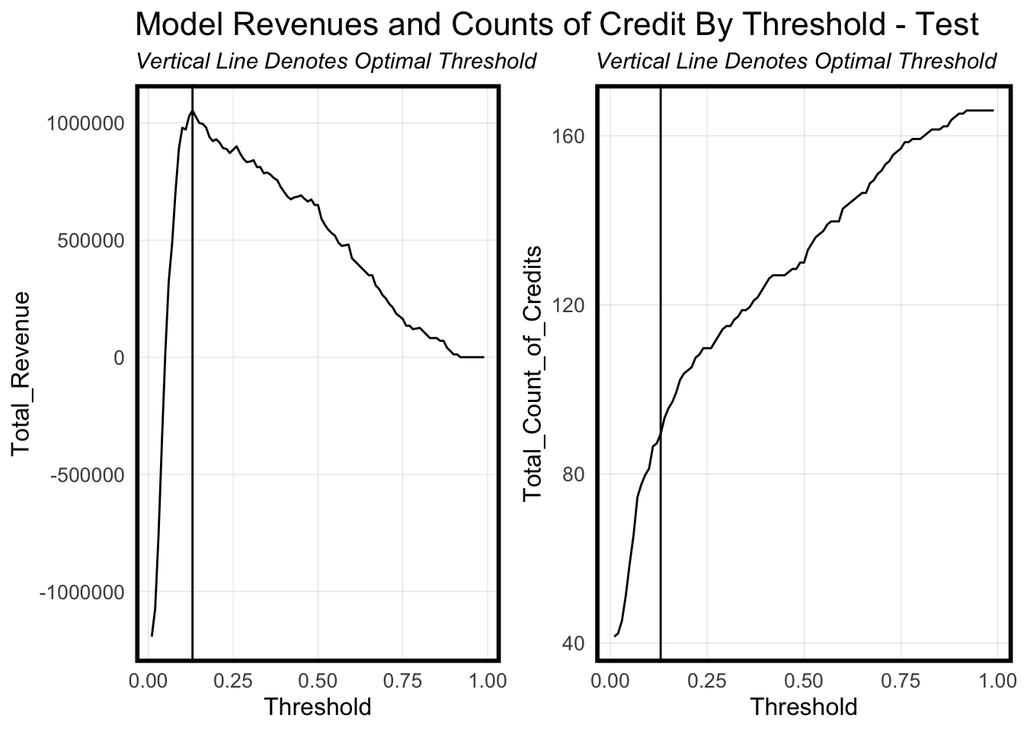

```r
grid.arrange(ncol = 2,
  ggplot(whichThreshold_sum)+
    geom_line(aes(x = Threshold, y = Total_Revenue))+
    geom_vline(xintercept =  optimalThreshold)+
    labs(title = "Model Revenues and Counts of Credit By Threshold - Test",
         subtitle = "Vertical Line Denotes Optimal Threshold") + plotTheme(),
  ggplot(whichThreshold_sum)+
    geom_line(aes(x = Threshold, y = Total_Count_of_Credits))+
    geom_vline(xintercept =  optimalThreshold)+
    labs(title = ' ', subtitle = "Vertical Line Denotes Optimal Threshold") + plotTheme())
```

Figure 3.2

Above the optimal threshold of 0.13, the predicted revenue would plummet until 0, although the revenue keeps increaseing from a negative value to the maximum value above 1 million. The total count of credits does maintain a growing pattern from the beginning.